A fundamental requirement to perform text mining is to get your text in a tidy format and perform word frequency analysis. Text is often in an unstructured format so performing even the most basic analysis requires some re-structuring. Thus, this first text mining tutorial covers the basics of text tidying and basic word frequency analysis.

## tl;dr

This tutorial serves as an introduction to basic text mining. First, I provide the data and packages required to replicate the analysis in this tutorial and then I walk through the basic operations to tidy unstructured text and perform word frequency analysis.

1. Replication requirements: What you’ll need to reproduce the analysis in this tutorial
2. Text tidying: Transforming your text into a tidy data structure
3. Word frequency analysis: Identifying the most common words in text

## Replication Requirements

This tutorial leverages the data provided in the [`harrypotter` package](https://github.com/bradleyboehmke/harrypotter). I constructed this package to supply the first seven novels in the Harry Potter series to illustrate text mining and analysis capabilities. You can load the `harrypotter` package with the following:

```r
if (packageVersion("devtools") < 1.6) {
  install.packages("devtools")
}

devtools::install_github("bradleyboehmke/harrypotter")
```

```r
library(tidyverse)      # data manipulation & plotting
library(stringr)        # text cleaning and regular expressions
library(tidytext)       # provides additional text mining functions
library(harrypotter)    # provides the first seven novels of the Harry Potter series
```

The seven novels we are working with, and are provided by the `harrypotter` package, include:

- `philosophers_stone`: Harry Potter and the Philosophers Stone, published in 1997
- `chamber_of_secrets`: Harry Potter and the Chamber of Secrets, published in 1998
- `prisoner_of_azkaban`: Harry Potter and the Prisoner of Azkaban, published in 1999
- `goblet_of_fire`: Harry Potter and the Goblet of Fire, published in 2000
- `order_of_the_phoenix`: Harry Potter and the Order of the Phoenix, published in 2003
- `half_blood_prince`: Harry Potter and the Half-Blood Prince, published in 2005
- `deathly_hallows`: Harry Potter and the Deathly Hallows, published in 2007

Each text is in a character vector with each element representing a single chapter. For instance, the following illustrates the raw text of the first two chapters of the `philosophers_stone`:

```r
philosophers_stone[1:2]
 [1] "THE BOY WHO LIVED　　Mr. and Mrs. Dursley, of number four, Privet Drive, were proud to say that they were perfectly normal, thank you very much. They were the last people you'd expect to be involved in anything strange or mysterious, because they just didn't hold with such nonsense.　　Mr. Dursley was the director of a firm called Grunnings, which made drills. He was a big, beefy man with hardly any neck, although he did have a very large mustache. Mrs. Dursley was thin and blonde and had nearly twice the usual amount of neck, which came in very useful as she spent so much of her time craning over garden fences, spying on the neighbors. The Dursleys had a small son called Dudley and in their opinion there was no finer boy anywhere.　　The Dursleys had everything they wanted, but they also had a secret, and their greatest fear was that somebody would discover it. They didn't think they could bear it if anyone found out about the Potters. Mrs. Potter was Mrs. Dursley's sister, but they hadn'... <truncated>
 [2] "THE VANISHING GLASS　　Nearly ten years had passed since the Dursleys had woken up to find their nephew on the front step, but Privet Drive had hardly changed at all. The sun rose on the same tidy front gardens and lit up the brass number four on the Dursleys' front door; it crept into their living room, which was almost exactly the same as it had been on the night when Mr. Dursley had seen that fateful news report about the owls. Only the photographs on the mantelpiece really showed how much time had passed. Ten years ago, there had been lots of pictures of what looked like a large pink beach ball wearing different-colored bonnets -- but Dudley Dursley was no longer a baby, and now the photographs showed a large blond boy riding his first bicycle, on a carousel at the fair, playing a computer game with his father, being hugged and kissed by his mother. The room held no sign at all that another boy lived in the house, too.　　Yet Harry Potter was still there, asleep at the moment, but no... <truncated>
```

## Text Tidying

Although we can do some simple regex analysis on this character vector, to properly analyze this text we want to turn it into a data frame or tibble. To do this on the `philosophers_stone` novel we could perform the following:

```r
text_tb <- tibble(chapter = seq_along(philosophers_stone),
                  text = philosophers_stone)

text_tb
## # A tibble: 17 × 2
##    chapter
##      <int>
## 1        1
## 2        2
## 3        3
## 4        4
## 5        5
## 6        6
## 7        7
## 8        8
## 9        9
## 10      10
## 11      11
## 12      12
## 13      13
## 14      14
## 15      15
## 16      16
## 17      17
## # ... with 1 more variables: text <chr>
```

This creates a 2-column tibble. The second column contains the full text for each chapter; however, this isn’t very conducive to future analyses. We can unnest these texts:

```r
text_tb %>%
        unnest_tokens(word, text)
## # A tibble: 77,875 × 2
##    chapter    word
##      <int>   <chr>
## 1        1     the
## 2        1     boy
## 3        1     who
## 4        1   lived
## 5        1      mr
## 6        1     and
## 7        1     mrs
## 8        1 dursley
## 9        1      of
## 10       1  number
## # ... with 77,865 more rows
```

Now we’ve split up the entire `philosophers_stone` text into a tibble that provides each word in each chapter. Its important to note that the `unnest_token` function does the following:

- splits the text into single words (you’ll learn about bi-grams, tri-grams, etc. in later tutorials)
- strips all punctuation
- converts each word to lowercase for easy comparability (use the `to_lower = FALSE` argument to turn this off)

This now lets us do some simple analysis on the `philosophers_stone` text; however, what if we want to analyze text across all seven novels? To do this we can perform the same steps by looping through each novel and then combining them.

```r
titles <- c("Philosopher's Stone", "Chamber of Secrets", "Prisoner of Azkaban",
            "Goblet of Fire", "Order of the Phoenix", "Half-Blood Prince",
            "Deathly Hallows")

books <- list(philosophers_stone, chamber_of_secrets, prisoner_of_azkaban,
           goblet_of_fire, order_of_the_phoenix, half_blood_prince,
           deathly_hallows)

series <- tibble()

for(i in seq_along(titles)) {

        clean <- tibble(chapter = seq_along(books[[i]]),
                        text = books[[i]]) %>%
             unnest_tokens(word, text) %>%
             mutate(book = titles[i]) %>%
             select(book, everything())

        series <- rbind(series, clean)
}

# set factor to keep books in order of publication
series$book <- factor(series$book, levels = rev(titles))

series
## # A tibble: 1,089,386 × 3
##                   book chapter    word
## *               <fctr>   <int>   <chr>
## 1  Philosopher's Stone       1     the
## 2  Philosopher's Stone       1     boy
## 3  Philosopher's Stone       1     who
## 4  Philosopher's Stone       1   lived
## 5  Philosopher's Stone       1      mr
## 6  Philosopher's Stone       1     and
## 7  Philosopher's Stone       1     mrs
## 8  Philosopher's Stone       1 dursley
## 9  Philosopher's Stone       1      of
## 10 Philosopher's Stone       1  number
## # ... with 1,089,376 more rows
```

We now have a tidy tibble with every individual word by chapter by book. We can now proceed to perform some simple word frequency analyses.

## Word Frequency

The simplest word frequency analysis is assessing the most common words in text. We can use `count` to assess the most common words across all the text in the Harry Potter series.

```r
series %>%
        count(word, sort = TRUE)
## # A tibble: 24,475 × 2
##     word     n
##    <chr> <int>
## 1    the 51593
## 2    and 27430
## 3     to 26985
## 4     of 21802
## 5      a 20966
## 6     he 20322
## 7  harry 16557
## 8    was 15631
## 9   said 14398
## 10   his 14264
## # ... with 24,465 more rows
```

One thing you will notice is that a lot of the most common words are not very informative (i.e. *the, and, to, of, a, he, …*). These are considered **stop** words. Most of the time we want our text mining to identify words that provide context (i.e. *harry, dumbledore, granger, afraid,* etc.). Thus, we can remove the stop words from our tibble with `anti_join` and the built-in `stop_words` data set provided by `tidytext`. Now we start to see characters and other nouns, verbs, and adjectives that we would expect to be common in this series.

```r
series %>%
        anti_join(stop_words) %>%
        count(word, sort = TRUE)
## # A tibble: 23,795 × 2
##          word     n
##         <chr> <int>
## 1       harry 16557
## 2         ron  5750
## 3    hermione  4912
## 4  dumbledore  2873
## 5      looked  2344
## 6   professor  2006
## 7      hagrid  1732
## 8        time  1713
## 9        wand  1639
## 10       eyes  1604
## # ... with 23,785 more rows
```

We can perform this same assessment but grouped by book or even each chapter within each book.

```r
# top 10 most common words in each book
series %>%
        anti_join(stop_words) %>%
        group_by(book) %>%
        count(word, sort = TRUE) %>%
        top_n(10)
## Source: local data frame [70 x 3]
## Groups: book [7]
##
##                    book     word     n
##                  <fctr>    <chr> <int>
## 1  Order of the Phoenix    harry  3730
## 2        Goblet of Fire    harry  2936
## 3       Deathly Hallows    harry  2770
## 4     Half-Blood Prince    harry  2581
## 5   Prisoner of Azkaban    harry  1824
## 6    Chamber of Secrets    harry  1503
## 7  Order of the Phoenix hermione  1220
## 8   Philosopher's Stone    harry  1213
## 9  Order of the Phoenix      ron  1189
## 10      Deathly Hallows hermione  1077
## # ... with 60 more rows
```

We can visualize this with

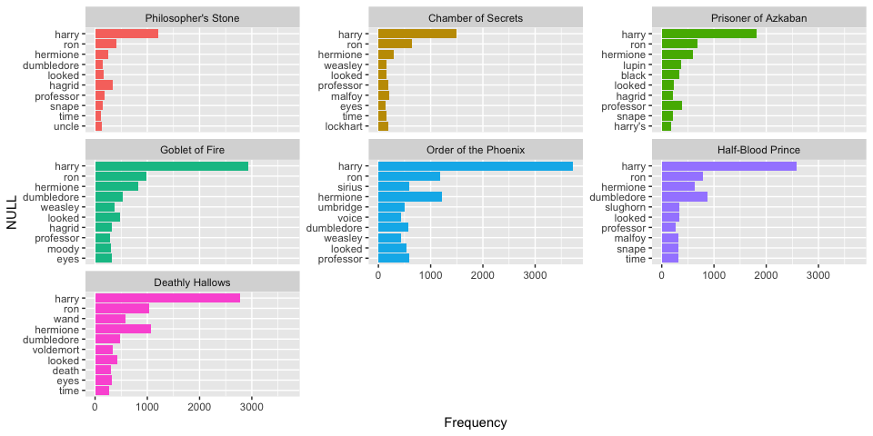

```r
# top 10 most common words in each book
series %>%
        anti_join(stop_words) %>%
        group_by(book) %>%
        count(word, sort = TRUE) %>%
        top_n(10) %>%
        ungroup() %>%
        mutate(book = factor(book, levels = titles),
               text_order = nrow(.):1) %>%
        ggplot(aes(reorder(word, text_order), n, fill = book)) +
          geom_bar(stat = "identity") +
          facet_wrap(~ book, scales = "free_y") +
          labs(x = "NULL", y = "Frequency") +
          coord_flip() +
          theme(legend.position="none")
```

Now, let’s calculate the frequency for each word across the entire Harry Potter series versus within each book. This will allow us to compare strong deviations of word frequency within each book as compared to across the entire series.

```r
# calculate percent of word use across all novels
potter_pct <- series %>%
        anti_join(stop_words) %>%
        count(word) %>%
        transmute(word, all_words = n / sum(n))

# calculate percent of word use within each novel
frequency <- series %>%
        anti_join(stop_words) %>%
        count(book, word) %>%
        mutate(book_words = n / sum(n)) %>%
        left_join(potter_pct) %>%
        arrange(desc(book_words)) %>%
        ungroup()

frequency
```

```
## # A tibble: 63,651 × 5
##                    book     word     n book_words  all_words
##                  <fctr>    <chr> <int>      <dbl>      <dbl>
## 1    Chamber of Secrets    harry  1503 0.04470420 0.04044824
## 2   Prisoner of Azkaban    harry  1824 0.04428474 0.04044824
## 3   Philosopher's Stone    harry  1213 0.04243484 0.04044824
## 4     Half-Blood Prince    harry  2581 0.04090462 0.04044824
## 5        Goblet of Fire    harry  2936 0.04040571 0.04044824
## 6  Order of the Phoenix    harry  3730 0.03854222 0.04044824
## 7       Deathly Hallows    harry  2770 0.03773533 0.04044824
## 8    Chamber of Secrets      ron   650 0.01933315 0.01404707
## 9   Prisoner of Azkaban      ron   690 0.01675245 0.01404707
## 10      Deathly Hallows hermione  1077 0.01467183 0.01199986
## # ... with 63,641 more rows
```

We can visualize this

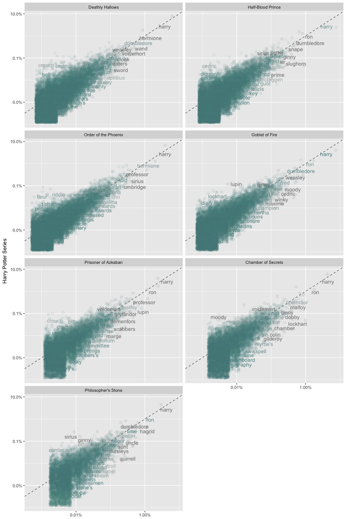

```r
ggplot(frequency, aes(x = book_words, y = all_words, color = abs(all_words - book_words))) +
        geom_abline(color = "gray40", lty = 2) +
        geom_jitter(alpha = 0.1, size = 2.5, width = 0.3, height = 0.3) +
        geom_text(aes(label = word), check_overlap = TRUE, vjust = 1.5) +
        scale_x_log10(labels = scales::percent_format()) +
        scale_y_log10(labels = scales::percent_format()) +
        scale_color_gradient(limits = c(0, 0.001), low = "darkslategray4", high = "gray75") +
        facet_wrap(~ book, ncol = 2) +
        theme(legend.position="none") +
        labs(y = "Harry Potter Series", x = NULL)
```

Words that are close to the line in these plots have similar frequencies across all the novels. For example, words such as “harry”, “ron”, “dumbledore” are fairly common and used with similar frequencies across most of the books. Words that are far from the line are words that are found more in one set of texts than another. Furthermore, words standing out above the line are common across the series but not within that book; whereas words below the line are common in that particular book but not across the series. For example, “cedric” stands out above the line in the Half-Blood Prince. This means that “cedric” is fairly common across the entire Harry Potter series but is not used as much in Half-Blood Prince. In contrast, a word below the line such as “quirrell” in the Philosopher’s Stone suggests this word is common in this novel but far less common across the series.

Let’s quantify how similar and different these sets of word frequencies are using a correlation test. How correlated are the word frequencies between the entire series and each book?

```r
frequency %>%
        group_by(book) %>%
        summarize(correlation = cor(book_words, all_words),
                  p_value = cor.test(book_words, all_words)$p.value)
## # A tibble: 7 × 3
##                   book correlation p_value
##                 <fctr>       <dbl>   <dbl>
## 1      Deathly Hallows   0.9703948       0
## 2    Half-Blood Prince   0.9703266       0
## 3 Order of the Phoenix   0.9844414       0
## 4       Goblet of Fire   0.9793959       0
## 5  Prisoner of Azkaban   0.9641515       0
## 6   Chamber of Secrets   0.9656789       0
## 7  Philosopher's Stone   0.9551352       0
```

The high correlations, which are all statistically significant (p-values < 0.0001), suggests that the relationship between the word frequencies is highly similar across the entire Harry Potter series.